# Fear on a Budget: How Production Philosophy Shapes Horror Film Profitability

Author

Wezizwe Harding

#### Setup

```r
library(tidyverse)
library(gt)

horror_movies <- read.csv("horror_movies.csv")
```

# Introduction

**NoteWhat makes a horror film profitable?**

Some might say: “Spend more and earn more.” Let’s find out if this is really true.

This project explores how **budget level** and **language market** interact to shape horror films’ profitability, and whether cultural production philosophy offers a convincing explanation for what the data reveals.

Hollywood horror typically follows a franchise model: high budgets, sequels and remakes.[^1]

However, Japanese horror (*J-horror*) has historically favoured low-budget, atmospherically driven filmmaking rooted in Shinto traditions where the threat cannot be defeated but only endured.[^2]

The dataset used here is Tanya Shapiro’s horror movie database[^3], featured in the “2022 Tidy Tuesday challenge,” containing over 32,000 horror films with the following relevant variables:

- budget, revenue, language, popularity, and vote averages.

```r
variables <- c("budget", "revenue", "language", "popularity", "vote averages")

descriptions <- c("float", "float", "string", "float", "float")
variables_tbl <- data.frame(
  attribute = variables,
  description = descriptions
)

gt(variables_tbl)
```

| attribute | description |
| --- | --- |
| budget | float |
| revenue | float |
| language | string |
| popularity | float |
| vote averages | float |

## Data Preparation

```r
# Keep only films where both budget and revenue are recorded and non-zero
df_clean <- horror_movies %>%
  filter(budget > 0, revenue > 0) %>%
  mutate(
    profitability = (revenue - budget) / budget,
    budget_cat = case_when(
      budget < 1000000                         ~ "Low (<$1M)",
      budget >= 1000000 & budget <= 10000000   ~ "Medium ($1–10M)",
      budget > 10000000                        ~ "High (>$10M)"
    ),
    budget_cat = factor(budget_cat,
                        levels = c("Low (<$1M)", "Medium ($1–10M)", "High (>$10M)"))
  ) %>%
  filter(!is.na(profitability), !is.infinite(profitability))

glimpse(df_clean)
```

[output not shown]

### Does Budget Level Predict Profitability?

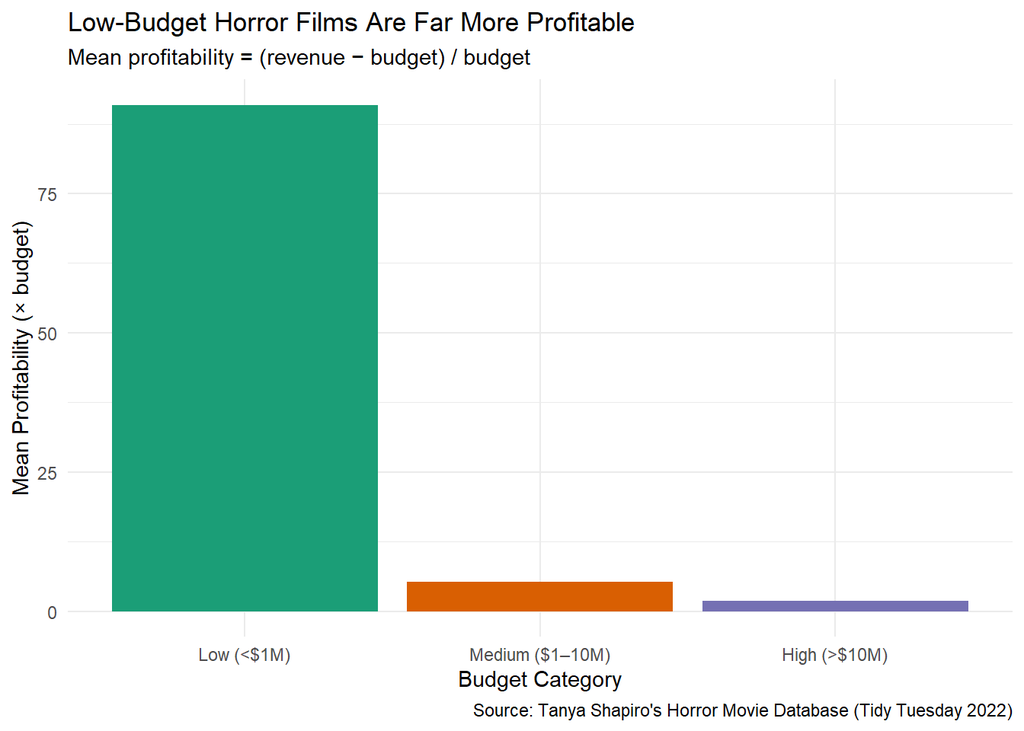

Figure 1

```r
df_budget <- df_clean %>%
  group_by(budget_cat) %>%
  summarise(
    mean_profitability = mean(profitability),
    n = n()
  )

ggplot(df_budget, aes(x = budget_cat, y = mean_profitability, fill = budget_cat)) +
  geom_col(show.legend = FALSE) +
  labs(
    title    = "Low-Budget Horror Films Are Far More Profitable",
    subtitle = "Mean profitability = (revenue − budget) / budget",
    x        = "Budget Category",
    y        = "Mean Profitability (× budget)",
    caption  = "Source: Tanya Shapiro's Horror Movie Database (Tidy Tuesday 2022)"
  ) +
  scale_fill_brewer(palette = "Dark2") +
  theme_minimal()
```

If low-budget films are mechanically more profitable, do markets that produce more low-budget films, like Japan, benefit simply by operating in that tier?

The next section examines whether language market adds any explanatory power beyond budget alone.

### Does Language Market Matter Too?

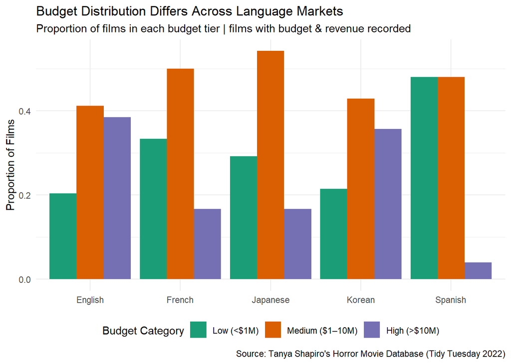

Figure 2

```r
df_lang <- df_clean %>%
  filter(original_language %in% c("en", "ja", "es", "fr", "ko")) %>%
  mutate(
    language_label = recode(original_language,
      en = "English", ja = "Japanese", es = "Spanish",
      fr = "French",  ko = "Korean"
    )
  )

budget_dist <- df_lang %>%
  count(language_label, budget_cat) %>%
  group_by(language_label) %>%
  mutate(proportion = n / sum(n)) %>%
  ungroup()

ggplot(budget_dist, aes(x = language_label, y = proportion, fill = budget_cat)) +
  geom_col(position = "dodge") +

  scale_fill_brewer(palette = "Dark2", name = "Budget Category") +
  labs(
    title    = "Budget Distribution Differs Across Language Markets",
    subtitle = "Proportion of films in each budget tier | films with budget & revenue recorded",
    x        = NULL,
    y        = "Proportion of Films",
    caption  = "Source: Tanya Shapiro's Horror Movie Database (Tidy Tuesday 2022)"
  ) +
  theme_minimal() +
  theme(legend.position = "bottom")
```

Japanese and Spanish films cluster in the low and medium categories, with very few high-budget productions. Korean horror is a notable exception, as it leans toward medium and high budgets. This matters because it begins to connect the cultural production argument to the data.

If J-horror’s low-budget style stems from a deliberate creative choice rather than limited spending, we would expect it to endure over time and continue to receive high audience ratings.

The table below looks at this idea:

### Profitability and Audience Reception by Language

```r
df_lang %>%
  group_by(language_label) %>%
  summarise(
    `Films` = n(),
    `Mean Profitability` = round(mean(profitability), 2),
    `Median Profitability` = round(median(profitability), 2),
    `Mean Vote Average` = round(mean(vote_average, na.rm = TRUE), 2),
    `Mean Popularity` = round(mean(popularity, na.rm = TRUE), 2),
    `Mean Budget (USD)` = round(mean(budget), 0),
    .groups = "drop"
  ) %>%
  arrange(desc(`Mean Profitability`)) %>%
  gt() %>%
  tab_header(
    title    = "Horror Film Performance by Language Market",
    subtitle = "Restricted to films with both budget and revenue recorded"
  ) %>%

  tab_caption("Source: Tanya Shapiro's Horror Movie Database (Tidy Tuesday 2022)")
```

Table 1: Source: Tanya Shapiro's Horror Movie Database (Tidy Tuesday 2022)

Horror Film Performance by Language Market

Restricted to films with both budget and revenue recorded

| language_label | Films | Mean Profitability | Median Profitability | Mean Vote Average | Mean Popularity | Mean Budget (USD) |
| --- | --- | --- | --- | --- | --- | --- |
| Japanese | 24 | 285.62 | 1.50 | 6.75 | 15.28 | 6485834 |
| Spanish | 25 | 83.01 | 0.46 | 6.09 | 17.81 | 2393490 |
| French | 12 | 61.91 | -0.03 | 6.97 | 20.08 | 5925254 |
| English | 936 | 17.93 | 1.12 | 5.80 | 33.31 | 14198283 |
| Korean | 14 | 5.19 | 1.48 | 6.03 | 25.16 | 8128841 |

#### Table Analysis

1. Japanese films have the highest mean profitability (around 286×) despite an average budget of approximately $6.5M higher than Spanish films ($2.4M) and comparable to French ($5.9M). Budget concentration in lower tiers is part of the story.
2. Japanese films do not have the highest vote average or popularity in this subset French films lead on votes, English on popularity. Profitability here is genuinely distinct from audience acclaim or reach.

# Discussion

The data supports a coherent story. Low-budget horror films are more profitable as a ratio of their production cost. However, budget alone does not explain everything. J-horror produces profit well above what its budget distribution would predict compared to films at similar budget levels, suggesting something specific to how those films are made and received.

The cultural production argument offers a plausible explanation. Hollywood’s franchise model inflates budgets to make sequels and pursue heavy marketing (with global distribution costs baked in). J-horror’s tradition of craft-led, low-cost storytelling produces films that can return astounding multiples on modest investments.

It is important to be honest about what the data cannot tell us. The sample of non-English films with both budget and revenue recorded is small (24 Japanese, 25 Spanish), so individual outliers carry significant weight in the means. This is an exploratory project: the patterns are suggestive and worth investigating further, not definitive.

# Conclusion

The scariest thing in this dataset may simply be what **Hollywood splurges…**

## Footnotes

[^1]: For more details, see the website:[Blog link](https://www.linkedin.com/pulse/how-low-budget-horror-filmmaking-could-shape-future-theatrical-jaran-z2e3e/).
[^2]: For more details, see the website:[Blog link](http://www.midnighteye.com/features/the-death-of-j-horror/).
[^3]: For more details, see the project website:[Project link](https://github.com/rfordatascience/tidytuesday/blob/master/data/2022/2022-11-01/readme.md).